# Traffic Accidents

25/11/2020

## The Data

- This presentation, will use a sample of data from 3.5 million traffic accident records.<sup>1,2</sup>
- A sample of 10000 has been taken to reduce the computational load when generating the document, and will be used to generate the preliminary statistics.
- A sample of 100 will then be used to generate an interactive Map
- This data is provided under the [CC BY-NC-SA 4.0](https://creativecommons.org/licenses/by-nc-sa/4.0/)

## Preliminary Statistics 1

- How does time of day influence the amount of accidents?

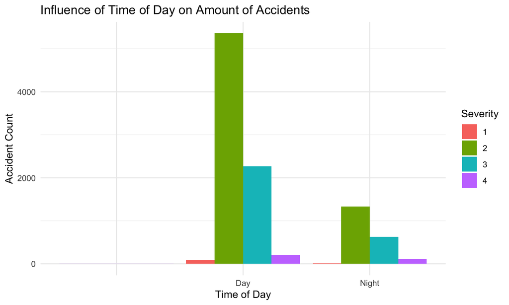

## Preliminary Statistics 2

- How does weather influence the amount of accidents?

[interactive table not shown]

## Preparing Mapped Accidents

- As 10,000 accidents is a lot to map on a single interactive map. Some measures should be taken to display only a sample of these points.
- For this we can use the function **sample_n()**, where a random sample of 100 accidents is taken from the database.

```r
location.samp.dat <- sample_n(location.dat,
                            size = 100,
                            replace = FALSE)
```

## Mapping Accidents

Then using the package [leaflet](https://leafletjs.com/), these sampled points can be plotted on an interactive map.

[interactive chart not shown]

## Surpise Equation

I couldn’t find another place to put this, so here is a multi-row equation.

\[ \begin{align} Sharks &= Grey, \\ Squirrels &= Grey, \\ Sharks &= Squirrels \end{align} \]

[figure not shown]

## Additional Note:

This presentation was based upon the in-development shiny project found [here](https://twise.shinyapps.io/Traffic_Accident_Dashboard/)

## References

1. Moosavi S, Samavatian MH, Parthasarathy S, Ramnath R. A countrywide traffic accident dataset. *arXiv preprint arXiv:190605409*. Published online 2019.

2. Moosavi S, Samavatian MH, Parthasarathy S, Teodorescu R, Ramnath R. Accident risk prediction based on heterogeneous sparse data: New dataset and insights. In: *Proceedings of the 27th Acm Sigspatial International Conference on Advances in Geographic Information Systems*.; 2019:33-42.